# Structural Complexity Indices

Mai Lazarus

2020-03-30

Install needed libraries if not already installed:

```r
is_inst <- function(pkg) {
  nzchar(system.file(package = pkg))
}

#Install the 'packman' library to easilly install additional libraries
if (!is_inst("pacman")) {install.packages("pacman")}

library("pacman")

p_load(dplyr, tidyverse, knitr ,tidyr, httr, reshape2, stringr, data.table,
       FD, corrplot, fractaldim, features, transport, pracma)
```

This script produces all structural complexity indices used in our study:

1. Functional diversity indices
2. Sky view factor indices
3. Common indices
4. Neighbors distance indices
5. Topographic position indices
6. FreeSpace index
7. EarthMovers index

For each of the groups, an Rmd file is sourced, where all functions are available. A short description of the essence and calculation of each of the aforementioned indices groups is also in the Rmd file. For full description please refer to the manuscript.

##Data

The necessary data for all functions should include 3 variables:

- Depth values along the bottom profile
- Their order, i.e. an acending sequence of numbers corresponding to the measurements
- An identification variable distinct for each bottom profile

For functions that require more data explanations are provided.

Step 1: import data Here is an example data, including 9000 depth measurements from 50 ‘transects’

```r
data = read.csv("simulation_data.csv")
head(data)
```

```
##   ID     depth point
## 1  1 -15.42941     1
## 2  1 -15.52010     2
## 3  1 -16.72426     3
## 4  1 -16.59976     4
## 5  1 -15.20889     5
## 6  1 -16.73757     6
```

Step 2: calculate structural complexity indices

#1. Functional diversity indices:#

[output not shown]

```
## [1] "functional diversity functions.md"
```

Calculate functional diversity (FD) indices: Here, 3 more arguments other than ‘data’ are required: 1. transect_length - the length of the transect, in m. 2. search distance - the distance in meters in which local extrama are searched from each focal measurement. 3. traits - a vector with the names of elements traits chosen for the calculation of functional diversity.

Three types of plots are created, presenting the bottom profile: For each transect, side by side: 1. Local extrema of all levels. 2. Structural elements within the profile, distinguished by colors.

3. A single plot presenting the correlations among structural elements traits.

Please refer to ‘functional diversity functions.Rmd’ for more details.

```r
FD_indices = indices_calc_fun(data,
                              transect_length = 25,
                              search_distance = 0.75,
                              traits = c("rugosity","vr","max_slope"))
```

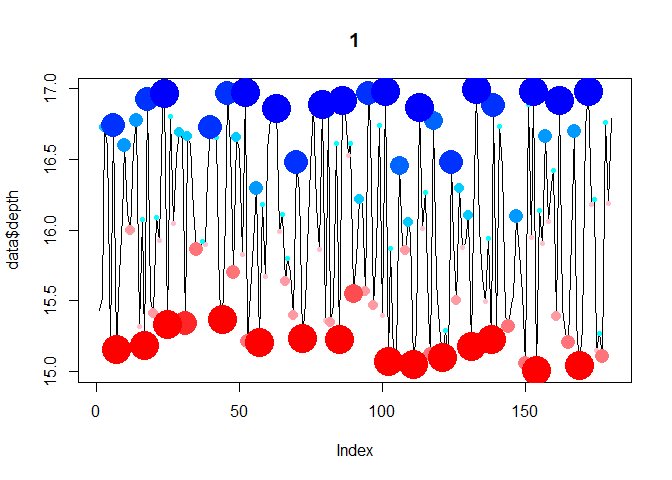

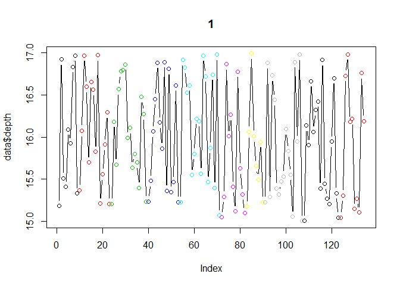

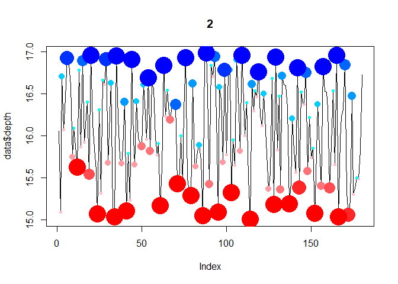

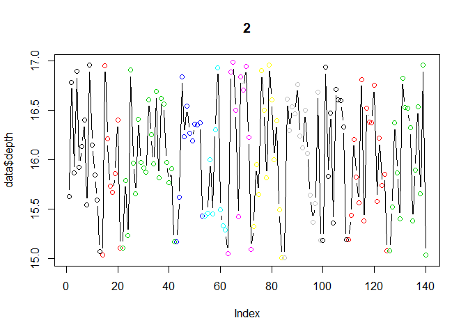

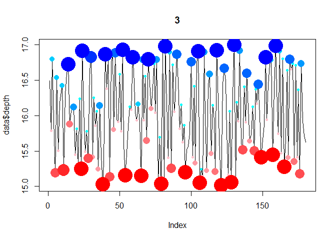

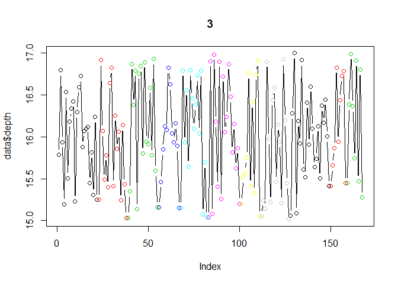

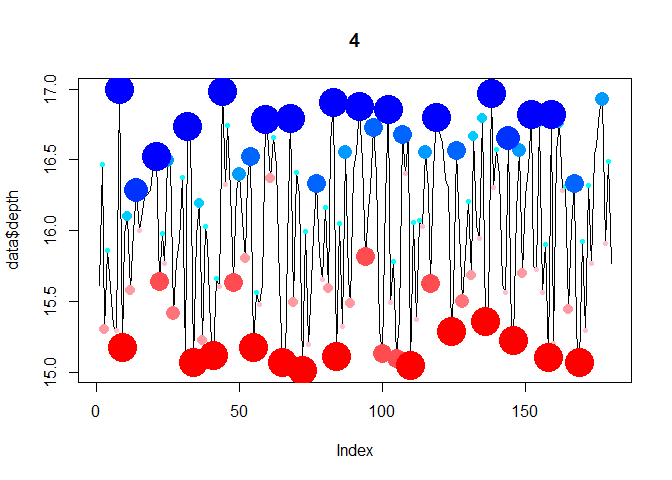

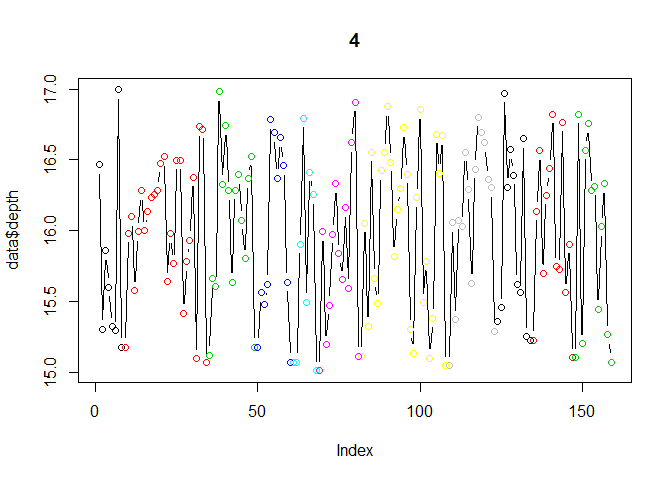

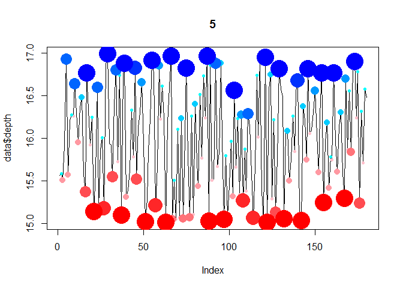

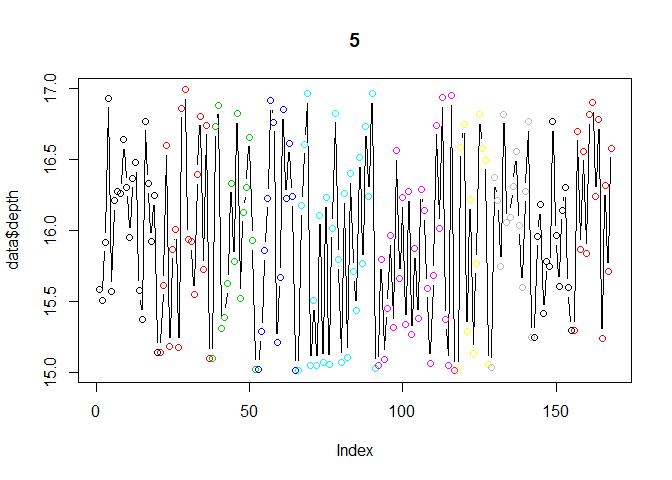

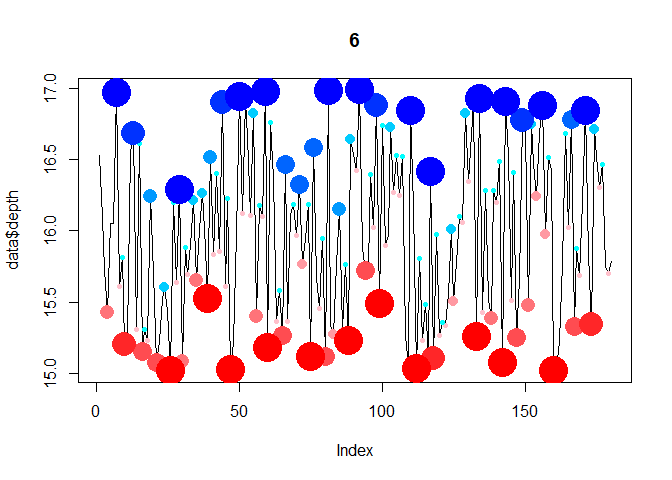

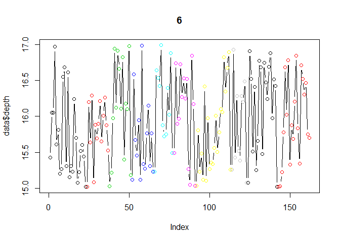

[89 more figures not shown]

#2. Sky view factor indices#

[output not shown]

```
## [1] "Sky view factor functions.md"
```

```r
SkyViewFactor = apply_svf_fun(data, radius_length = 2.5, threshold = .3, transect_length = 25, edges_to_remove = 2.5)
```

#3. Common indices

[output not shown]

```
## [1] "common_indices_functions.md"
```

Calculate common indices indices:

```r
common_indices = common_fun(data)
```

#4. Neighbors distance indices

[output not shown]

```
## [1] "neighbors_functions.md"
```

Calculate Neighbors distance indices indices:

```r
neighbors_indices = neighbors_indices_fun(data)
```

#5. Topographic position indices - Max concavity/convexity

[output not shown]

```
## [1] "TPI functions.md"
```

Calculate Max concavity/convexity indices indices:

```r
Max_concave_convex_indices = Max_concave_convex_fun(data)
```

#6. FreeSpace index

[output not shown]

```
## [1] "FreeSpace functions.md"
```

Calculate FreeSpace index:

```r
FreeSpace_index = FreeSpace_fun(data)
```

#7. EarthMovers index

[output not shown]

```
## [1] "EarthMovers functions.md"
```

Calculate EarthMovers indices:

```r
EarthMovers_data = wass_fun(data)
```

Join all indices data:

```r
complexity_indices = Reduce(function(x, y) merge(x, y, by = "ID", all = TRUE), list(FD_indices, SkyViewFactor, common_indices, neighbors_indices, Max_concave_convex_indices, FreeSpace_index, EarthMovers_data))
```